# Practical Machine Learning

Edurne

7 de octubre de 2015

# *INTRODUCTION*

Using devices such as Jawbone Up, Nike FuelBand, and Fitbit it is now possible to collect a large amount of data about personal activity relatively inexpensively. These type of devices are part of the quantified self movement - a group of enthusiasts who take measurements about themselves regularly to improve their health, to find patterns in their behavior, or because they are tech geeks. One thing that people regularly do is quantify how much of a particular activity they do, but they rarely quantify how well they do it. In this project, our goal will be to use data from accelerometers on the belt, forearm, arm, and dumbell of 6 participants. They were asked to perform barbell lifts correctly and incorrectly in 5 different ways.

# *OBTAINING DATA*

First, we download the 2 datasets: training and test datasets. Moreover, we load the required libraries for the anlysis.

```r
library(bitops);library(RCurl)
library(lattice);library(ggplot2);library(caret)
library(randomForest)
library(foreach);library(iterators);library(parallel);library(doParallel)
library(survival); library(splines);library(gbm)
setwd("C:/Users/ealonso/Desktop/Coursera R/Practical Machine Learning/")#working directory

x <- getURL("https://d396qusza40orc.cloudfront.net/predmachlearn/pml-training.csv", ssl.verifypeer = FALSE)
y <- getURL("https://d396qusza40orc.cloudfront.net/predmachlearn/pml-testing.csv", ssl.verifypeer = FALSE)
train <- read.csv(textConnection(x))
test <- read.csv(textConnection(y))

save("train", file="./train.RData")
save("test", file="./test.RData")
```

# *EXPLORATION AND CLEANING DATA*

We can see that we have 19,622 observations and 160 variables in training dataset. For testing dataset, we have 20 observations and 160 variables.

```r
dim(train);dim(test)
```

```
## [1] 19622   160
```

```
## [1]  20 160
```

```r
summary(train$classe)
```

```
##    A    B    C    D    E
## 5580 3797 3422 3216 3607
```

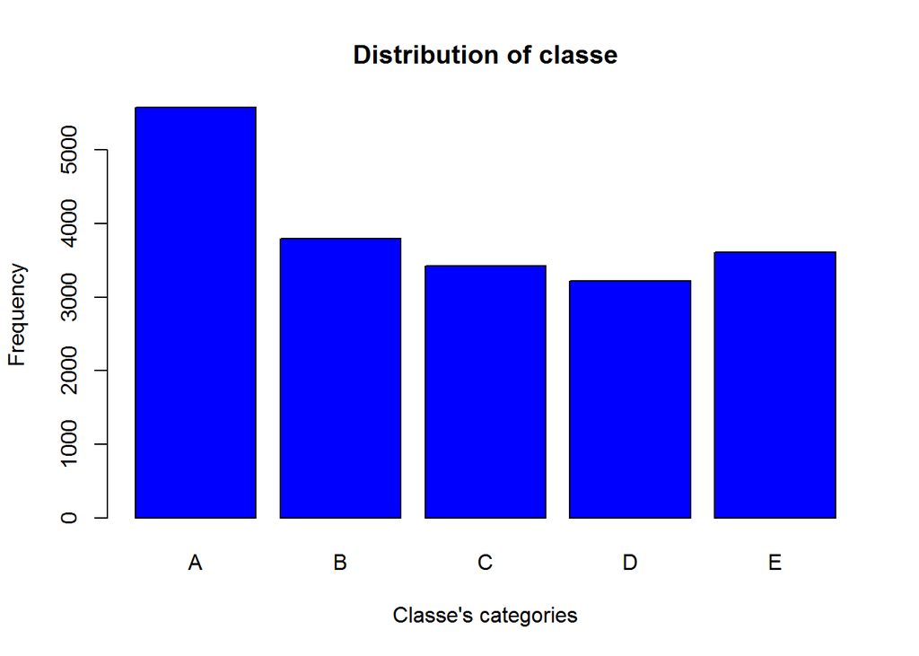

```r
plot(train$classe, main = "Distribution of classe", xlab = "Classe's categories", ylab = "Frequency", col="blue")
```

Moreover, it was showed the frequency of the categories of predictor variable (“classe”).

Now, we start to clean the dataset. There are many variables with missing values. We are going to delete those variables which have at least the 90% of observations missing.

```r
NAs <- apply(train, 2, function(x) {sum(is.na(x))})
train <- train[,which(NAs <  nrow(train)*0.9)]
```

Although this is not the best solution we are going to delete those variables with a variance near zero.

```r
remove_var <- nearZeroVar(train, saveMetrics = TRUE)
train <- train[, remove_var$nzv == FALSE]
```

Finally, we are going to delete the following variables because they don’t give us interesting information: x, user name, raw timestamp part 1 and 2, cvtd timestamp and num window (the first six variables).

```r
train <- train[,7:ncol(train)]
```

# *DATA ANALYSIS*

## Data partition

We are going to divide our training dataset with the aim of validate the model. Usually, it is used 60% of observations as train dataset and 40% as validation dataset.

```r
set.seed(1978)#For making reproductible the analysis

particion <- createDataPartition(train$classe, p=0.6,list=FALSE);
training <- train[particion,]
testing <- train[-particion,]
```

## Building the model

I am going to contrast between two models: random forest (RfModel) and boosted regression trees (GbmModel).

```r
registerDoParallel(makeCluster(detectCores()))#for multi-core
RfModel <- train(classe ~ .,  method ="rf", data = training)
GbmModel <- train(classe ~ ., method = "gbm", data = training)
```

## Accuracy of models

Now, we calculted the accuracy of models built:

```r
Rf_accuracy<- predict(RfModel, testing)
print(confusionMatrix(Rf_accuracy, testing$classe))
```

```
## Confusion Matrix and Statistics
##
##           Reference
## Prediction    A    B    C    D    E
##          A 2228   19    0    0    0
##          B    4 1496   11    1    2
##          C    0    3 1354   20    5
##          D    0    0    3 1263    6
##          E    0    0    0    2 1429
##
## Overall Statistics
##
##                Accuracy : 0.9903
##                  95% CI : (0.9879, 0.9924)
##     No Information Rate : 0.2845
##     P-Value [Acc > NIR] : < 2.2e-16
##
##                   Kappa : 0.9877
##  Mcnemar's Test P-Value : NA
##
## Statistics by Class:
##
##                      Class: A Class: B Class: C Class: D Class: E
## Sensitivity            0.9982   0.9855   0.9898   0.9821   0.9910
## Specificity            0.9966   0.9972   0.9957   0.9986   0.9997
## Pos Pred Value         0.9915   0.9881   0.9797   0.9929   0.9986
## Neg Pred Value         0.9993   0.9965   0.9978   0.9965   0.9980
## Prevalence             0.2845   0.1935   0.1744   0.1639   0.1838
## Detection Rate         0.2840   0.1907   0.1726   0.1610   0.1821
## Detection Prevalence   0.2864   0.1930   0.1761   0.1621   0.1824
## Balanced Accuracy      0.9974   0.9913   0.9927   0.9904   0.9953
```

```r
Gbm_accuracy<- predict(GbmModel , testing)
print(confusionMatrix(Gbm_accuracy, testing$classe))
```

```
## Confusion Matrix and Statistics
##
##           Reference
## Prediction    A    B    C    D    E
##          A 2198   47    0    0    7
##          B   21 1435   53    6   25
##          C    9   35 1299   40   13
##          D    3    0   16 1235   23
##          E    1    1    0    5 1374
##
## Overall Statistics
##
##                Accuracy : 0.9611
##                  95% CI : (0.9566, 0.9653)
##     No Information Rate : 0.2845
##     P-Value [Acc > NIR] : < 2.2e-16
##
##                   Kappa : 0.9508
##  Mcnemar's Test P-Value : 1.278e-15
##
## Statistics by Class:
##
##                      Class: A Class: B Class: C Class: D Class: E
## Sensitivity            0.9848   0.9453   0.9496   0.9603   0.9528
## Specificity            0.9904   0.9834   0.9850   0.9936   0.9989
## Pos Pred Value         0.9760   0.9318   0.9305   0.9671   0.9949
## Neg Pred Value         0.9939   0.9868   0.9893   0.9922   0.9895
## Prevalence             0.2845   0.1935   0.1744   0.1639   0.1838
## Detection Rate         0.2801   0.1829   0.1656   0.1574   0.1751
## Detection Prevalence   0.2870   0.1963   0.1779   0.1628   0.1760
## Balanced Accuracy      0.9876   0.9644   0.9673   0.9770   0.9759
```

We can see in this output that the accuracy of the ramdom forest model was 0.9903 (95% confidence interlval: (0.9879, 0.9924)) and for the boosted regression tree was 0.9611 (95% CI: (0.9566, 0.9653)). Finally, I decide to use the random forest because its accuracy is higher (the accuracy graph is presented below).

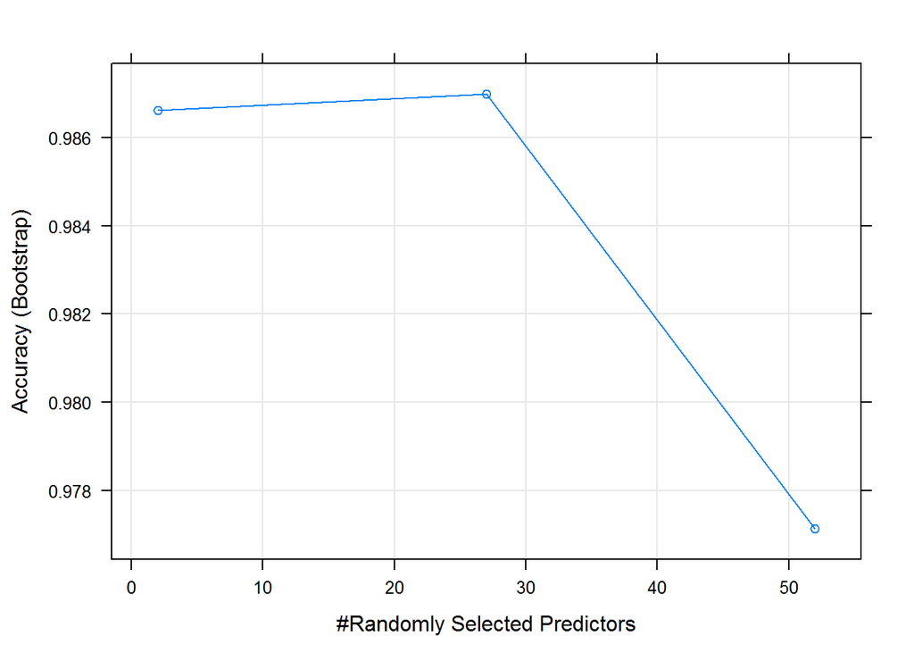

```r
plot(RfModel, log="y")
```

## Variable importance

Now, we are going to explore the importance of variables for model selected.

```r
PI <- varImp(RfModel$finalModel)
PI$var <-rownames(PI)
PI <- as.data.frame(PI[with(PI, order(PI$Overall, decreasing=TRUE)), ])
rownames(PI) <- NULL
print(PI)
```

```
##       Overall                  var
## 1  1193.85864            roll_belt
## 2   737.42403        pitch_forearm
## 3   636.32379             yaw_belt
## 4   542.28816    magnet_dumbbell_y
## 5   536.62671         roll_forearm
## 6   529.85370    magnet_dumbbell_z
## 7   529.49375           pitch_belt
## 8   272.20320     accel_dumbbell_y
## 9   222.93789      accel_forearm_x
## 10  215.01878        roll_dumbbell
## 11  208.66462    magnet_dumbbell_x
## 12  207.99279     magnet_forearm_z
## 13  192.70717        magnet_belt_z
## 14  181.38056     accel_dumbbell_z
```

[output cut: 38 more lines]

We can see that the most important variable for predinting classe is roll belt following by pitch forearm.

# **Testing data**

We use the program given in the exercise of Coursera for prediction assignment:

```r
#Prediction Assignment Submission
predictions <- predict(RfModel, test)
#Function given in exercises
pml_write_files = function(x){
  n = length(x)
  for(i in 1:n){
    filename = paste0("problem_id_",i,".txt")
    write.table(x[i],file=filename,quote=FALSE,row.names=FALSE,col.names=FALSE)
  }
}
pml_write_files(predictions)
```